```python
import pickle
%matplotlib inline
import numpy as np
import matplotlib
import matplotlib.pyplot as plt
import scipy
from scipy import stats
import pandas as pd
```

```python
infile1 = open ("higgs_100000_pt_1000_1200.pkl",'rb')
dictH = pickle.load(infile1)
infile2 = open ("qcd_100000_pt_1000_1200.pkl",'rb')
dictQ = pickle.load(infile2)
```

# Problem 1

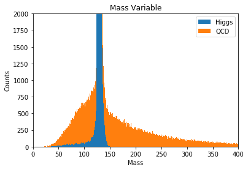

```python
plt.title('Mass Variable')
plt.xlabel('Mass')
plt.ylabel('Counts')
plt.hist([dictH['mass'],dictQ['mass']],bins=800,density=False,alpha=1,label=['Higgs','QCD'],stacked=True);
#plt.hist(dictH['mass'],bins=800,density=False,alpha=.5,label='Higgs',stacked=True);
plt.ylim(0,2000);
plt.legend()
plt.xlim(0,400);
```

```python
n_higgs = 50
n_qcd = 2000
```

```python
sig_p = stats.poisson.cdf(2050,mu=2000)
exp_sig = stats.norm.ppf(sig_p)
print(exp_sig)
calc_sig = (n_higgs)/np.sqrt(n_qcd)
print(calc_sig)
print('Difference = '+str(exp_sig-calc_sig))
```

```
1.1282230087754428
1.118033988749895
Difference = 0.01018902002554789
```

# Problem 2

```python
sig_p = stats.poisson.cdf(2050,mu=2000)
exp_sig = stats.norm.ppf(sig_p)
print(exp_sig)
```

```
1.1282230087754428
```

```python
sigsleft = np.zeros(40)
for i in range(1,41):
    maskH = ((90+i)<dictH['mass'])&(dictH['mass']<150)
    CUTH = dictH['mass'][maskH]
    maskQ = ((90+i)<dictQ['mass'])&(dictQ['mass']<150)
    CUTQ = dictQ['mass'][maskQ]
    nhiggs = (len(CUTH)/100000) * n_higgs
    nqcd = (len(CUTQ)/100000) * n_qcd
    sig_perc = stats.poisson.cdf(nqcd+nhiggs,mu=nqcd)
    sigsleft[i-1] = stats.norm.ppf(sig_perc)
sigsleft[33] # so 34+90 gives highest significance from the left (124)
```

```
2.6188118919874657
```

```python
sigsright = np.zeros(40)
for i in range(1,41):
    maskH = ((124)<dictH['mass'])&(dictH['mass']<150-i)
    CUTH = dictH['mass'][maskH]
    maskQ = ((124)<dictQ['mass'])&(dictQ['mass']<150-i)
    CUTQ = dictQ['mass'][maskQ]
    nhiggs = (len(CUTH)/100000) * n_higgs
    nqcd = (len(CUTQ)/100000) * n_qcd
    sig_perc = stats.poisson.cdf(nqcd+nhiggs,mu=nqcd)
    sigsright[i-1] = stats.norm.ppf(sig_perc)
sigsright[20] # so 150-21 gives highest sig overall (129)
# OPTIMIZED range is 124:129
```

```
4.004006485304592
```

Below is checking the optimized cut values:

```python
maskOH = (124<dictH['mass'])&(dictH['mass']<129)
CUTmassH = dictH['mass'][maskOH]

maskOQ = (124<dictQ['mass'])&(dictQ['mass']<129)
CUTmassQ = dictQ['mass'][maskOQ]
numhig1 = (len(CUTmassH)/100000)*50
numqcd1 = (len(CUTmassQ)/100000)*2000
stats.norm.ppf(stats.poisson.cdf(numhig1+numqcd1,mu=numqcd1))
```

```
4.004006485304592
```

# Problem 3

For all graphs in problem 3, the stacked histogram on the left represents the uncut data, while the histogram on the right corresponds to the optimal mass cut histogram masked onto the other features.

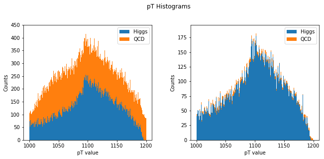

```python
plt.subplots(1,2)
plt.suptitle('pT Histograms',x=.80,y=1.15)
plt.subplots_adjust(left=.125,right=1.5,top=1,bottom=.2,
                   wspace=.3,hspace=.01)
plt.subplot(1,2,1)
plt.ylabel('Counts')
plt.xlabel('pT value')
plt.hist([dictH['pt'],dictQ['pt']],bins=800,density=False,alpha=1,label=['Higgs','QCD'],stacked=True);
plt.legend();
plt.subplot(1,2,2)
plt.hist([dictH['pt'][maskOH],dictQ['pt'][maskOQ]],bins=800,density=False,alpha=1,label=['Higgs','QCD'],stacked=True);
plt.ylabel('Counts')
plt.xlabel('pT value')
plt.legend();
```

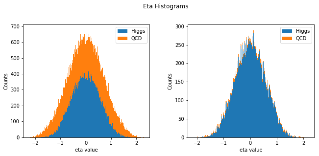

```python
plt.subplots(1,2)
plt.suptitle('Eta Histograms',x=.80,y=1.15)
plt.subplots_adjust(left=.125,right=1.5,top=1,bottom=.2,
                   wspace=.3,hspace=.01)
plt.subplot(1,2,1)
plt.ylabel('Counts')
plt.hist([dictH['eta'],dictQ['eta']],bins=800,density=False,alpha=1,label=['Higgs','QCD'],stacked=True);
plt.xlabel('eta value')
plt.legend();
plt.subplot(1,2,2)
plt.hist([dictH['eta'][maskOH],dictQ['eta'][maskOQ]],bins=800,density=False,alpha=1,label=['Higgs','QCD'],stacked=True);
plt.ylabel('Counts')
plt.xlabel('eta value')
plt.legend();
```

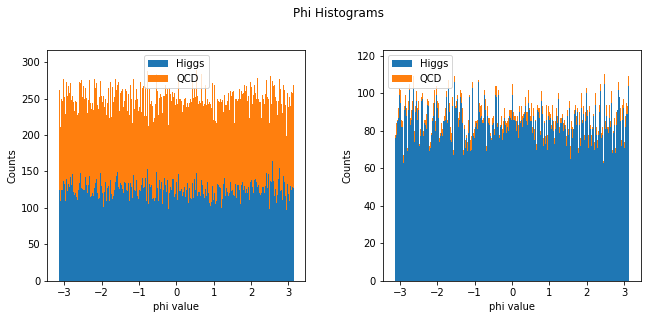

```python
plt.subplots(1,2)
plt.suptitle('Phi Histograms',x=.80,y=1.15)
plt.subplots_adjust(left=.125,right=1.5,top=1,bottom=.2,
                   wspace=.3,hspace=.01)
plt.subplot(1,2,1)
plt.ylabel('Counts')
plt.hist([dictH['phi'],dictQ['phi']],bins=800,density=False,alpha=1,label=['Higgs','QCD'],stacked=True);
plt.xlabel('phi value')
plt.legend();
plt.subplot(1,2,2)
plt.hist([dictH['phi'][maskOH],dictQ['phi'][maskOQ]],bins=800,density=False,alpha=1,label=['Higgs','QCD'],stacked=True);
plt.ylabel('Counts')
plt.xlabel('phi value')
plt.legend();
```

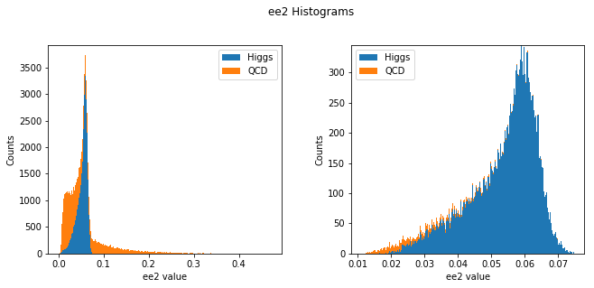

```python
plt.subplots(1,2)
plt.suptitle('ee2 Histograms',x=.80,y=1.15)
plt.subplots_adjust(left=.125,right=1.5,top=1,bottom=.2,
                   wspace=.3,hspace=.01)
plt.subplot(1,2,1)
plt.ylabel('Counts')
plt.hist([dictH['ee2'],dictQ['ee2']],bins=800,density=False,alpha=1,label=['Higgs','QCD'],stacked=True);
plt.xlabel('ee2 value')
plt.legend();
plt.subplot(1,2,2)
plt.hist([dictH['ee2'][maskOH],dictQ['ee2'][maskOQ]],bins=800,density=False,alpha=1,label=['Higgs','QCD'],stacked=True);
plt.ylabel('Counts')
plt.xlabel('ee2 value')
plt.legend();
```

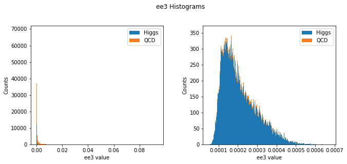

```python
plt.subplots(1,2)
plt.suptitle('ee3 Histograms',x=.80,y=1.15)
plt.subplots_adjust(left=.125,right=1.5,top=1,bottom=.2,
                   wspace=.3,hspace=.01)
plt.subplot(1,2,1)
plt.ylabel('Counts')
plt.hist([dictH['ee3'],dictQ['ee3']],bins=800,density=False,alpha=1,label=['Higgs','QCD'],stacked=True);
plt.xlabel('ee3 value')
plt.legend();
plt.subplot(1,2,2)
plt.hist([dictH['ee3'][maskOH],dictQ['ee3'][maskOQ]],bins=800,density=False,alpha=1,label=['Higgs','QCD'],stacked=True);
plt.ylabel('Counts')
plt.xlabel('ee3 value')
plt.legend();
```

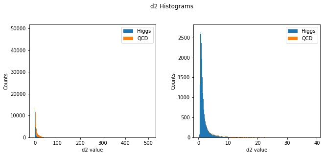

```python
plt.subplots(1,2)
plt.suptitle('d2 Histograms',x=.80,y=1.15)
plt.subplots_adjust(left=.125,right=1.5,top=1,bottom=.2,
                   wspace=.3,hspace=.01)
plt.subplot(1,2,1)
plt.ylabel('Counts')
plt.hist([dictH['d2'],dictQ['d2']],bins=800,density=False,alpha=1,label=['Higgs','QCD'],stacked=True);
plt.xlabel('d2 value')
plt.legend();
plt.subplot(1,2,2)
plt.hist([dictH['d2'][maskOH],dictQ['d2'][maskOQ]],bins=800,density=False,alpha=1,label=['Higgs','QCD'],stacked=True);
plt.ylabel('Counts')
plt.xlabel('d2 value')
plt.legend();
```

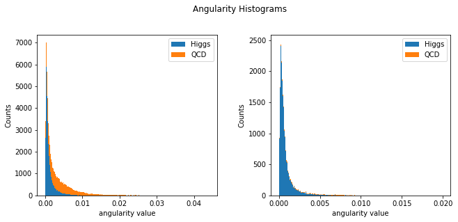

```python
plt.subplots(1,2)
plt.suptitle('Angularity Histograms',x=.80,y=1.15)
plt.subplots_adjust(left=.125,right=1.5,top=1,bottom=.2,
                   wspace=.3,hspace=.01)
plt.subplot(1,2,1)
plt.ylabel('Counts')
plt.hist([dictH['angularity'],dictQ['angularity']],bins=800,density=False,alpha=1,label=['Higgs','QCD'],stacked=True);
plt.xlabel('angularity value')
plt.legend();
plt.subplot(1,2,2)
plt.hist([dictH['angularity'][maskOH],dictQ['angularity'][maskOQ]],bins=800,density=False,alpha=1,label=['Higgs','QCD'],stacked=True);
plt.ylabel('Counts')
plt.xlabel('angularity value')
plt.legend();
```

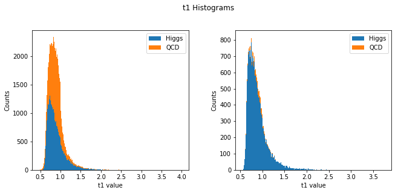

```python
plt.subplots(1,2)
plt.suptitle('t1 Histograms',x=.80,y=1.15)
plt.subplots_adjust(left=.125,right=1.5,top=1,bottom=.2,
                   wspace=.3,hspace=.01)
plt.subplot(1,2,1)
plt.ylabel('Counts')
plt.hist([dictH['t1'],dictQ['t1']],bins=800,density=False,alpha=1,label=['Higgs','QCD'],stacked=True);
plt.xlabel('t1 value')
plt.legend();
plt.subplot(1,2,2)
plt.hist([dictH['t1'][maskOH],dictQ['t1'][maskOQ]],bins=800,density=False,alpha=1,label=['Higgs','QCD'],stacked=True);
plt.ylabel('Counts')
plt.xlabel('t1 value')
plt.legend();
```

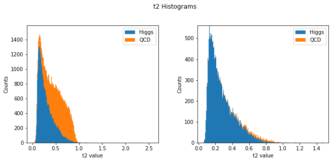

```python
plt.subplots(1,2)
plt.suptitle('t2 Histograms',x=.80,y=1.15)
plt.subplots_adjust(left=.125,right=1.5,top=1,bottom=.2,
                   wspace=.3,hspace=.01)
plt.subplot(1,2,1)
plt.ylabel('Counts')
plt.hist([dictH['t2'],dictQ['t2']],bins=800,density=False,alpha=1,label=['Higgs','QCD'],stacked=True);
plt.xlabel('t2 value')
plt.legend();
plt.subplot(1,2,2)
plt.hist([dictH['t2'][maskOH],dictQ['t2'][maskOQ]],bins=800,density=False,alpha=1,label=['Higgs','QCD'],stacked=True);
plt.ylabel('Counts')
plt.xlabel('t2 value')
plt.legend();
```

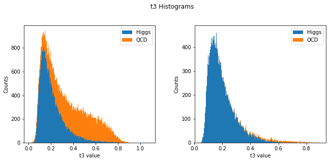

```python
plt.subplots(1,2)
plt.suptitle('t3 Histograms',x=.80,y=1.15)
plt.subplots_adjust(left=.125,right=1.5,top=1,bottom=.2,
                   wspace=.3,hspace=.01)
plt.subplot(1,2,1)
plt.ylabel('Counts')
plt.hist([dictH['t3'],dictQ['t3']],bins=800,density=False,alpha=1,label=['Higgs','QCD'],stacked=True);
plt.xlabel('t3 value')
plt.legend();
plt.subplot(1,2,2)
plt.hist([dictH['t3'][maskOH],dictQ['t3'][maskOQ]],bins=800,density=False,alpha=1,label=['Higgs','QCD'],stacked=True);
plt.ylabel('Counts')
plt.xlabel('t3 value')
plt.legend();
```

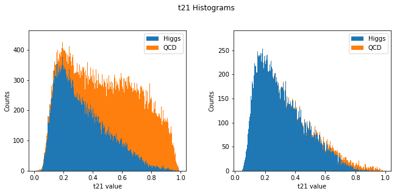

```python
plt.subplots(1,2)
plt.suptitle('t21 Histograms',x=.80,y=1.15)
plt.subplots_adjust(left=.125,right=1.5,top=1,bottom=.2,
                   wspace=.3,hspace=.01)
plt.subplot(1,2,1)
plt.ylabel('Counts')
plt.hist([dictH['t21'],dictQ['t21']],bins=800,density=False,alpha=1,label=['Higgs','QCD'],stacked=True);
plt.xlabel('t21 value')
plt.legend();
plt.subplot(1,2,2)
plt.hist([dictH['t21'][maskOH],dictQ['t21'][maskOQ]],bins=800,density=False,alpha=1,label=['Higgs','QCD'],stacked=True);
plt.ylabel('Counts')
plt.xlabel('t21 value')
plt.legend();
```

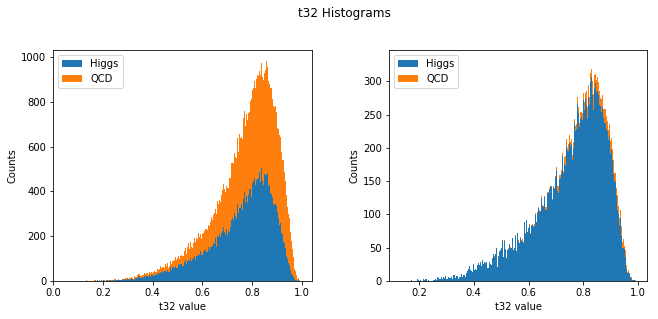

```python
plt.subplots(1,2)
plt.suptitle('t32 Histograms',x=.80,y=1.15)
plt.subplots_adjust(left=.125,right=1.5,top=1,bottom=.2,
                   wspace=.3,hspace=.01)
plt.subplot(1,2,1)
plt.ylabel('Counts')
plt.hist([dictH['t32'],dictQ['t32']],bins=800,density=False,alpha=1,label=['Higgs','QCD'],stacked=True);
plt.xlabel('t32 value')
plt.legend();
plt.subplot(1,2,2)
plt.hist([dictH['t32'][maskOH],dictQ['t32'][maskOQ]],bins=800,density=False,alpha=1,label=['Higgs','QCD'],stacked=True);
plt.ylabel('Counts')
plt.xlabel('t32 value')
plt.legend();
```

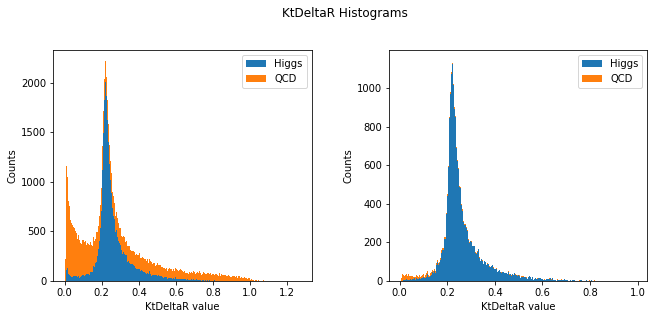

```python
plt.subplots(1,2)
plt.suptitle('KtDeltaR Histograms',x=.80,y=1.15)
plt.subplots_adjust(left=.125,right=1.5,top=1,bottom=.2,
                   wspace=.3,hspace=.01)
plt.subplot(1,2,1)
plt.ylabel('Counts')
plt.hist([dictH['KtDeltaR'],dictQ['KtDeltaR']],bins=800,density=False,alpha=1,label=['Higgs','QCD'],stacked=True);
plt.xlabel('KtDeltaR value')
plt.legend();
plt.subplot(1,2,2)
plt.hist([dictH['KtDeltaR'][maskOH],dictQ['KtDeltaR'][maskOQ]],bins=800,density=False,alpha=1,label=['Higgs','QCD'],stacked=True);
plt.ylabel('Counts')
plt.xlabel('KtDeltaR value')
plt.legend();
```

# Problem 4

There is another cut that could be made to increase significance, seen in the cut d2 histogram. A portion of the background on that histogram is seen to be clearly separate from the signal data.

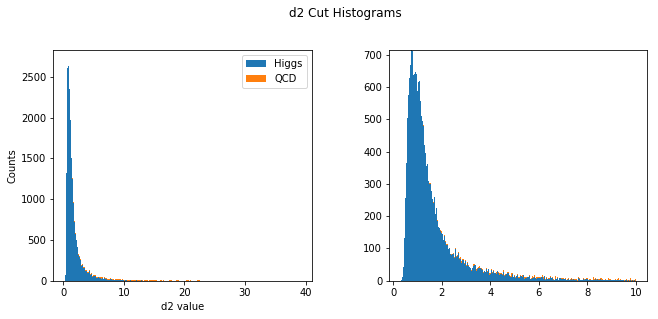

```python
plt.subplots(1,2)
plt.suptitle('d2 Cut Histograms',x=.80,y=1.15)
plt.subplots_adjust(left=.125,right=1.5,top=1,bottom=.2,
                   wspace=.3,hspace=.01)
plt.subplot(1,2,1)
plt.hist([dictH['d2'][maskOH],dictQ['d2'][maskOQ]],bins=800,density=False,alpha=1,label=['Higgs','QCD'],stacked=True);
plt.ylabel('Counts')
plt.xlabel('d2 value')
plt.legend();

plt.subplot(1,2,2)
masked1 = dictH['d2'][maskOH]
masked2 = dictQ['d2'][maskOQ]
optcutH = ((0<dictH['d2'][maskOH])&(dictH['d2'][maskOH]<10))
optcutQ = ((0<dictQ['d2'][maskOQ])&(dictQ['d2'][maskOQ]<10))
plt.hist([masked1[optcutH],masked2[optcutQ]],bins=800,density=False,alpha=1,label=['Higgs','QCD'],stacked=True);
```

The significance for this cut is as follows:

```python
cutd2H = masked1[optcutH]
cutd2Q = masked2[optcutQ]
numhig = (len(cutd2H)/100000)*50
numqcd = (len(cutd2Q)/100000)*2000
stats.norm.ppf(stats.poisson.cdf(numhig+numqcd,mu=numqcd))
```

```
5.005161955195693
```

An improvement of 1.001 sigma was achieved after additionally cutting the d2 data. My partner found a signfiance of 3.03 after the mass cut and a significance of 8.13 after the d2 cut.

# Lab 8

```python
import h5py
```

```python
hl = h5py.File('data_highLumi_pt_1000_1200.h5', 'r')
dataHL = hl.get('data').get('block0_values')
ll = h5py.File('data_lowLumi_pt_1000_1200.h5', 'r')
dataLL = ll.get('data').get('block0_values')
hl['data']['block0_items'][:]
```

```
array([b'pt', b'eta', b'phi', b'mass', b'ee2', b'ee3', b'd2',
       b'angularity', b't1', b't2', b't3', b't21', b't32', b'KtDeltaR'],
      dtype='|S10')
```

# Problem 1 - High Luminosity

Feature #1 - Mass

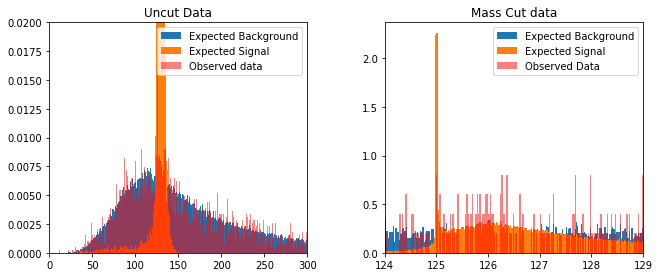

```python
plt.subplots(1,2)
plt.subplots_adjust(left=.125,right=1.5,top=1,bottom=.2,
                   wspace=.3,hspace=.01)
plt.subplot(121)
plt.title('Uncut Data')
# vals = plt.hist(dictQ['mass'],bins=800,visible=False);
# vals2 = plt.hist(dictH['mass'],bins=800,visible=False);
# bincount = vals[0]*.04066
# plt.bar(vals[1][0:800],bincount,width=1,label='Expected Background')
# bincount2 = vals2[0]*.04066
# plt.bar(vals2[1][0:800],bincount2,width=1,label='Expected Signal')
# plt.hist(dataHL[:,3],bins=800,density=False,alpha=.6,color='red',label='Observed data');
# plt.xlim(25,300)
# plt.legend()
# plt.ylim(0,45);
plt.hist(dictQ['mass'],bins=800,density=True,label='Expected Background')
plt.hist(dictH['mass'],bins=800,density=True,label='Expected Signal')
plt.hist(dataHL[:,3],bins=800,density=True,alpha=.5,color='red',label='Observed data');
plt.xlim(0,300)
plt.ylim(0,.02)
plt.legend()

plt.subplot(122)
plt.title('Mass Cut data')
# vals3 = plt.hist(dictQ['mass'][maskOQ],bins=400,visible=False)
# vals4 = plt.hist(dictH['mass'][maskOH],bins=400,visible=False)
obscut = ((124<dataHL[:,3])&(dataHL[:,3]<129))
# bincount3 = vals3[0]*((len(dataHL[:,3][obscut])/len(dictQ['mass'][maskOQ])))
# bincount4 = vals4[0]*((len(dataHL[:,3][obscut])/len(dictH['mass'][maskOH])))
# plt.bar(vals3[1][0:400],bincount3,width=.0125,label='Expected Background')
# plt.bar(vals4[1][0:400],bincount4,width=.0125,label='Expected Signal')
# plt.hist(dataHL[:,3][obscut],bins=400,alpha=.6,color='red',label='Observed data')
# plt.xlim(124,129)
# plt.ylim(0,10)
# plt.legend();
plt.hist(dictQ['mass'][maskOQ],bins=200,density=True,label='Expected Background')
plt.hist(dictH['mass'][maskOH],bins=200,density=True,label='Expected Signal')
plt.hist(dataHL[:,3][obscut],bins=200,density=True,alpha=.5,color='red',label='Observed Data');
plt.xlim(124,129)
plt.legend();
```

```python
new_obsN = 50*(len(dataHL[:,3]))/len(dictH['mass'])
new_obsQ = 2000*(len(dataHL[:,3]))/len(dictQ['mass'])


print('Expected Significance: '+str(stats.norm.ppf(stats.poisson.cdf(numhig1+numqcd1,mu=numqcd1))))
cut_obsN = (len(dataHL[:,3][obscut]))/len(dataHL[:,3])
print('Observed Significance: '+str(stats.norm.ppf(stats.poisson.cdf((new_obsN*cut_obsN)+(new_obsQ*cut_obsN),mu=(new_obsQ*cut_obsN)))))
```

```
Expected Significance: 4.004006485304592
Observed Significance: 0.3287745118692216
```

Feature #2 - d2

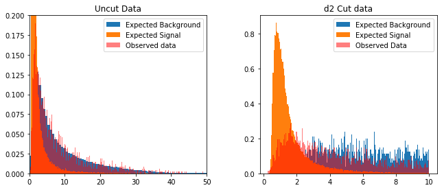

```python
plt.subplots(1,2)
plt.subplots_adjust(left=.125,right=1.5,top=1,bottom=.2,
                   wspace=.3,hspace=.01)
plt.subplot(121)
plt.title('Uncut Data')
# vals = plt.hist(dictQ['d2'],bins=800,visible=False);
# vals2 = plt.hist(dictH['d2'],bins=800,visible=False);
# bincount = vals[0]*.04066
# plt.bar(vals[1][0:800],bincount,width=1,label='Expected Background')
# bincount2 = vals2[0]*.04066
# plt.bar(vals2[1][0:800],bincount2,width=1,label='Expected Signal')
# plt.hist(dataHL[:,6],bins=800,density=False,alpha=.6,color='red',label='Observed data');
# plt.xlim(0,40)
# plt.legend()
# plt.ylim(0,700);
plt.hist(dictQ['d2'],bins=800,density=True,label='Expected Background')
plt.hist(dictH['d2'],bins=800,density=True,label='Expected Signal')
plt.hist(dataHL[:,6],bins=800,density=True,alpha=.5,color='red',label='Observed data');
plt.xlim(0,50)
plt.ylim(0,.2)
plt.legend()

plt.subplot(122)
plt.title('d2 Cut data')
# vals3 = plt.hist(masked2[optcutQ],bins=400,visible=False)
# vals4 = plt.hist(masked1[optcutH],bins=400,visible=False)
obscut = ((0<dataHL[:,6])&(dataHL[:,6]<10))
# bincount3 = vals3[0]*((len(dataHL[:,6][obscut])/len(masked2[optcutQ])))
# bincount4 = vals4[0]*((len(dataHL[:,6][obscut])/len(masked1[optcutH])))
# plt.bar(vals3[1][0:400],bincount3,width=.025,label='Expected Background')
# plt.bar(vals4[1][0:400],bincount4,width=.025,label='Expected Signal')
# plt.hist(dataHL[:,6][obscut],bins=400,alpha=.6,color='red',label='Observed data')
# plt.xlim(0,10)
# plt.ylim(0,60)
plt.hist(masked2[optcutQ],bins=200,density=True,label='Expected Background')
plt.hist(masked1[optcutH],bins=200,density=True,label='Expected Signal')
plt.hist(dataHL[:,6][obscut],bins=200,density=True,alpha=.5,color='red',label='Observed Data');
plt.legend();
```

Similar to the mass histograms above, the left represents the uncut data with the observed data and the right represents the cut data with the cut observed data. The significance of the cut observed is seen below.

```python
new_obsN = 50*(len(dataHL[:,6]))/len(dictH['d2'])
new_obsQ = 2000*(len(dataHL[:,6]))/len(dictQ['d2'])


print('Expected Significance: '+str(stats.norm.ppf(stats.poisson.cdf(numhig+numqcd,mu=numqcd))))
cut_obsN = (len(dataHL[:,6][obscut]))/len(dataHL[:,6])
print('Observed Significance: '+str(stats.norm.ppf(stats.poisson.cdf((new_obsN*cut_obsN)+(new_obsQ*cut_obsN),mu=(new_obsQ*cut_obsN)))))
```

```
Expected Significance: 5.005161955195693
Observed Significance: 0.25806489391138887
```

# Problem 2 - Low Luminosity

Feature #1 - Mass

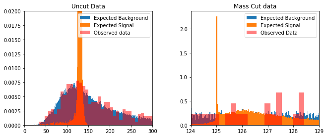

```python
plt.subplots(1,2)
plt.subplots_adjust(left=.125,right=1.5,top=1,bottom=.2,
                   wspace=.3,hspace=.01)
plt.subplot(121)
plt.title('Uncut Data')
# vals = plt.hist(dictQ['mass'],bins=800,visible=False);
# vals2 = plt.hist(dictH['mass'],bins=800,visible=False);
# bincount = vals[0]*(len(dataLL)/100000)
# plt.bar(vals[1][0:800],bincount,width=1,label='Expected Background')
# bincount2 = vals2[0]*(len(dataLL)/100000)
# plt.bar(vals2[1][0:800],bincount2,width=1,label='Expected Signal')
# plt.hist(dataLL[:,3],bins=800,density=False,alpha=.6,color='red',label='Observed data');
# plt.xlim(25,300)
# plt.legend()
# plt.ylim(0,45);
plt.hist(dictQ['mass'],bins=800,density=True,label='Expected Background')
plt.hist(dictH['mass'],bins=800,density=True,label='Expected Signal')
plt.hist(dataLL[:,3],bins=80,density=True,alpha=.5,color='red',label='Observed data');
plt.xlim(0,300)
plt.ylim(0,.02)
plt.legend()

plt.subplot(122)
plt.title('Mass Cut data')
# vals3 = plt.hist(dictQ['mass'][maskOQ],bins=400,visible=False)
# vals4 = plt.hist(dictH['mass'][maskOH],bins=400,visible=False)
obscut = ((124<dataLL[:,3])&(dataLL[:,3]<129))
# bincount3 = vals3[0]*((len(dataLL[:,3][obscut])/len(dictQ['mass'][maskOQ])))
# bincount4 = vals4[0]*((len(dataLL[:,3][obscut])/len(dictH['mass'][maskOH])))
# plt.bar(vals3[1][0:400],bincount3,width=.025,label='Expected Background')
# plt.bar(vals4[1][0:400],bincount4,width=.025,label='Expected Signal')
# plt.hist(dataLL[:,3][obscut],bins=100,alpha=.6,color='red',label='Observed data')
# plt.xlim(124,129)
# plt.ylim(0,5)
plt.hist(dictQ['mass'][maskOQ],bins=200,density=True,label='Expected Background')
plt.hist(dictH['mass'][maskOH],bins=200,density=True,label='Expected Signal')
plt.hist(dataLL[:,3][obscut],bins=20,density=True,alpha=.5,color='red',label='Observed Data');
plt.xlim(124,129)
plt.legend();
```

The left is uncut, while the right is cut data. Since there is 1/10 the data compared to the high luminosity data, the bin size is 10x larger. Significance is calculated below.

```python
new_obsN = 50*(len(dataLL[:,3]))/len(dictH['mass'])
new_obsQ = 2000*(len(dataLL[:,3]))/len(dictQ['mass'])


print('Expected Significance: '+str(stats.norm.ppf(stats.poisson.cdf(numhig1+numqcd1,mu=numqcd1))))
cut_obsN = (len(dataLL[:,3][obscut]))/len(dataLL[:,3])
print('Observed Significance: '+str(stats.norm.ppf(stats.poisson.cdf((new_obsN*cut_obsN)+(new_obsQ*cut_obsN),mu=(new_obsQ*cut_obsN)))))
```

```
Expected Significance: 4.004006485304592
Observed Significance: 0.44079707962943737
```

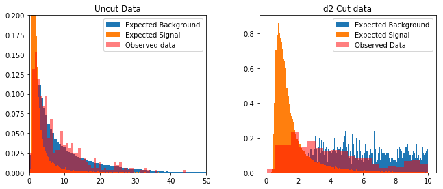

```python
plt.subplots(1,2)
plt.subplots_adjust(left=.125,right=1.5,top=1,bottom=.2,
                   wspace=.3,hspace=.01)
plt.subplot(121)
plt.title('Uncut Data')
# vals = plt.hist(dictQ['d2'],bins=800,visible=False);
# vals2 = plt.hist(dictH['d2'],bins=800,visible=False);
# bincount = vals[0]*.04066
# plt.bar(vals[1][0:800],bincount,width=1,label='Expected Background')
# bincount2 = vals2[0]*.04066
# plt.bar(vals2[1][0:800],bincount2,width=1,label='Expected Signal')
# plt.hist(dataHL[:,6],bins=800,density=False,alpha=.6,color='red',label='Observed data');
# plt.xlim(0,40)
# plt.legend()
# plt.ylim(0,700);
plt.hist(dictQ['d2'],bins=800,density=True,label='Expected Background')
plt.hist(dictH['d2'],bins=800,density=True,label='Expected Signal')
plt.hist(dataLL[:,6],bins=80,density=True,alpha=.5,color='red',label='Observed data');
plt.xlim(0,50)
plt.ylim(0,.2)
plt.legend()

plt.subplot(122)
plt.title('d2 Cut data')
# vals3 = plt.hist(masked2[optcutQ],bins=400,visible=False)
# vals4 = plt.hist(masked1[optcutH],bins=400,visible=False)
obscut = ((0<dataLL[:,6])&(dataLL[:,6]<10))
# bincount3 = vals3[0]*((len(dataHL[:,6][obscut])/len(masked2[optcutQ])))
# bincount4 = vals4[0]*((len(dataHL[:,6][obscut])/len(masked1[optcutH])))
# plt.bar(vals3[1][0:400],bincount3,width=.025,label='Expected Background')
# plt.bar(vals4[1][0:400],bincount4,width=.025,label='Expected Signal')
# plt.hist(dataHL[:,6][obscut],bins=400,alpha=.6,color='red',label='Observed data')
# plt.xlim(0,10)
# plt.ylim(0,60)
plt.hist(masked2[optcutQ],bins=200,density=True,label='Expected Background')
plt.hist(masked1[optcutH],bins=200,density=True,label='Expected Signal')
plt.hist(dataLL[:,6][obscut],bins=20,density=True,alpha=.5,color='red',label='Observed Data');
plt.legend();
```

The left represents the pre-cut data, the right is the cut data. The bin count for the observed data was divided by 10 compared to the expected data due to the factor of 10 smaller data amount that the low luminosity data has.

```python
new_obsN = 50*(len(dataLL[:,6]))/len(dictH['mass'])
new_obsQ = 2000*(len(dataLL[:,6]))/len(dictQ['mass'])


print('Expected Significance: '+str(stats.norm.ppf(stats.poisson.cdf(numhig+numqcd,mu=numqcd))))
cut_obsN = (len(dataLL[:,6][obscut]))/len(dataLL[:,6])
print('Observed Significance: '+str(stats.norm.ppf(stats.poisson.cdf((new_obsN*cut_obsN)+(new_obsQ*cut_obsN),mu=(new_obsQ*cut_obsN)))))
```

```
Expected Significance: 5.005161955195693
Observed Significance: 0.1708105114103634
```

# Problem 3

```python
obs_conf = stats.poisson.ppf(q=.95,mu=.1708105)
print('Observed confidence interval upper limit: '+str(obs_conf))
```

[output not shown]

```python
exp_conf = stats.poisson.ppf(q=.95,mu=5.005)
print('Expected confidence interval upper limit: '+str(exp_conf))
```

```
Expected confidence interval upper limit: 9.0
```

The expected upper limit is larger than the observed limit. This could be due to the amount of data given in the expected data pool compared to the smaller amount from the observed data. More data means better accuracy in measurements.